# ggplot2 : 2. Line Graphs

```r
# install.packages(c('ggplot2’, 'gcookbook’), dependencies = TRUE)
library(ggplot2)
library(gcookbook)
```

## Making a Basic Line Graph

```r
str(BOD)
```

```
## 'data.frame':    6 obs. of  2 variables:
##  $ Time  : num  1 2 3 4 5 7
##  $ demand: num  8.3 10.3 19 16 15.6 19.8
##  - attr(*, "reference")= chr "A1.4, p. 270"
```

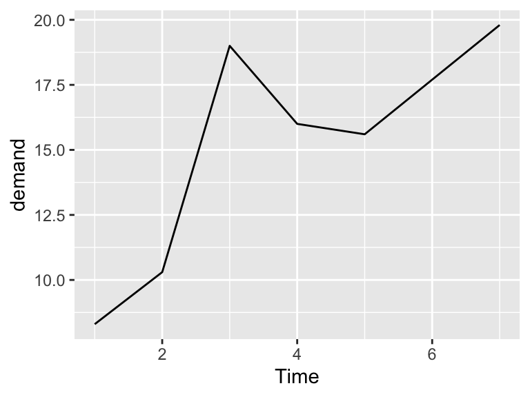

```r
ggplot(BOD, aes(x = Time, y = demand)) + geom_line()  # x is numeric
```

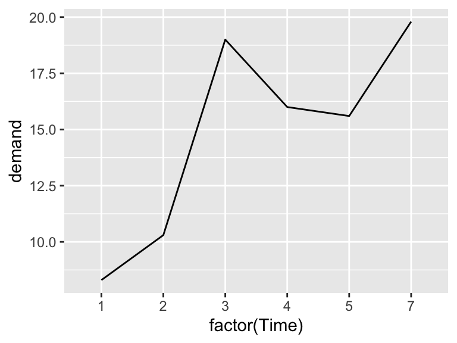

```r
ggplot(BOD, aes(x = factor(Time), y = demand, group = 1)) + geom_line()
```

- `geom_line()` : line graph를 그림.
- x 변수의 특성이 numeric 혹은 factor 여부에 따라 x 축의 스케일이 달라짐.
- x 변수가 factor이고 line으로 연결하기 위해 `group = 1` (그룹변수가 없음. 혹은 모든 자료가 하나의 그룹임을 의미) 을 지정함.

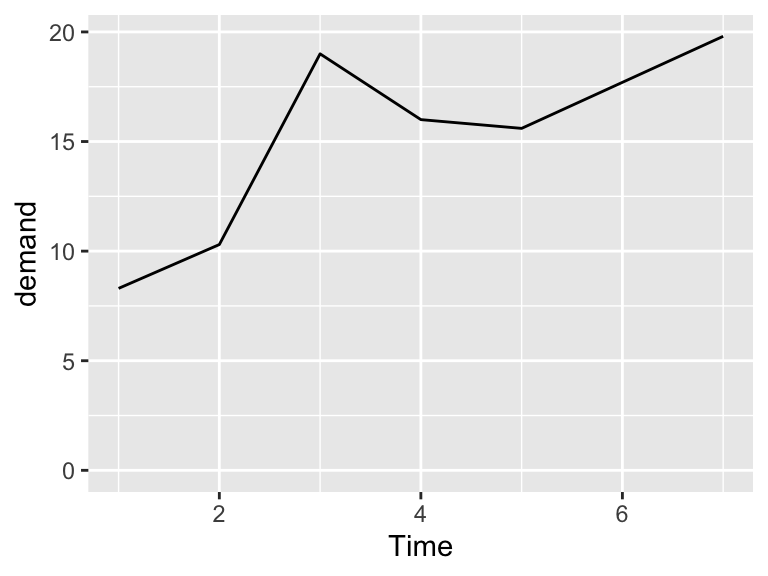

```r
ggplot(BOD, aes(x = Time, y = demand)) + geom_line() +
  ylim(0, max(BOD$demand))
```

- `ylim(0, max(BOD$demand))` 는 y축의 범위를 0부터 y변수(BOD 데이터의 demand 변수)의 최대값으로 설정.

## Adding Points to a Line Graph

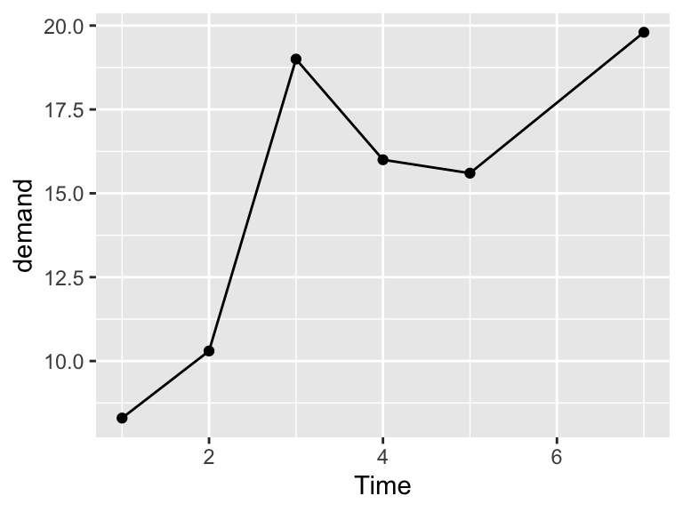

```r
ggplot(BOD, aes(x = Time, y = demand)) + geom_line() + geom_point()
```

- 함수 `geom_point()`를 추가하면 점을 그림에 출력.
- 크기, 색상, 모양을 변화시키기 위한 다양항 옵션 제공.

```r
str(worldpop)
```

```
## 'data.frame':    58 obs. of  2 variables:
##  $ Year      : int  -10000 -9000 -8000 -7000 -6000 -5000 -4000 -3000 -2000 -1000 ...
##  $ Population: int  2431 3564 5136 7562 11461 17920 28370 44820 72108 115066 ...
```

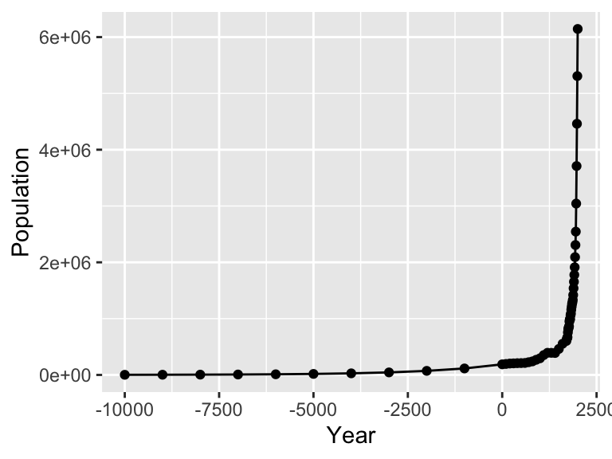

```r
p <- ggplot(worldpop, aes(x = Year, y = Population)) + geom_line() + geom_point()
p
```

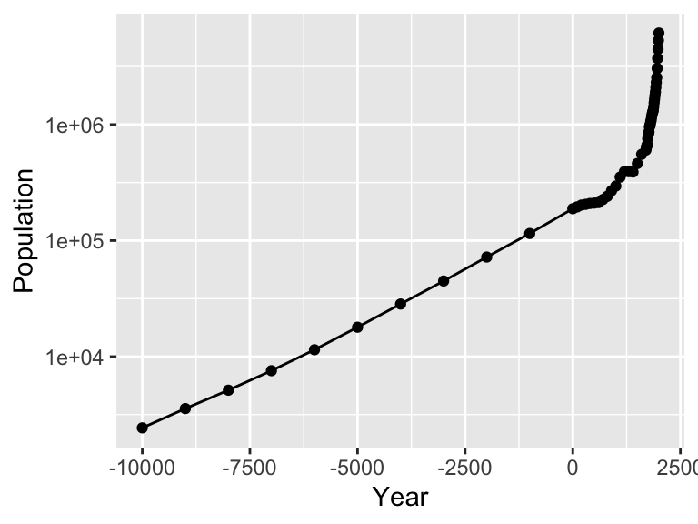

```r
p + scale_y_log10()
```

- 함수 `scale_y_log10()` 은 y축의 스케일을 log10 스케일로 변환

## Making a Line Graph with Multiple Lines

```r
str(ToothGrowth)
```

```
## 'data.frame':    60 obs. of  3 variables:
##  $ len : num  4.2 11.5 7.3 5.8 6.4 10 11.2 11.2 5.2 7 ...
##  $ supp: Factor w/ 2 levels "OJ","VC": 2 2 2 2 2 2 2 2 2 2 ...
##  $ dose: num  0.5 0.5 0.5 0.5 0.5 0.5 0.5 0.5 0.5 0.5 ...
```

```r
library(plyr)
tg <- ddply(ToothGrowth, c('supp', 'dose'), summarise, length = mean(len))
tg
```

```
##   supp dose length
## 1   OJ  0.5  13.23
## 2   OJ  1.0  22.70
## 3   OJ  2.0  26.06
## 4   VC  0.5   7.98
## 5   VC  1.0  16.77
## 6   VC  2.0  26.14
```

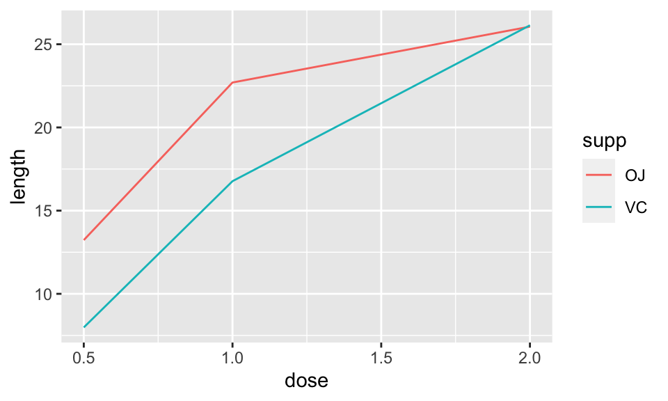

```r
# map supp to color
ggplot(tg, aes(x = dose, y = length, color = supp)) + geom_line()
```

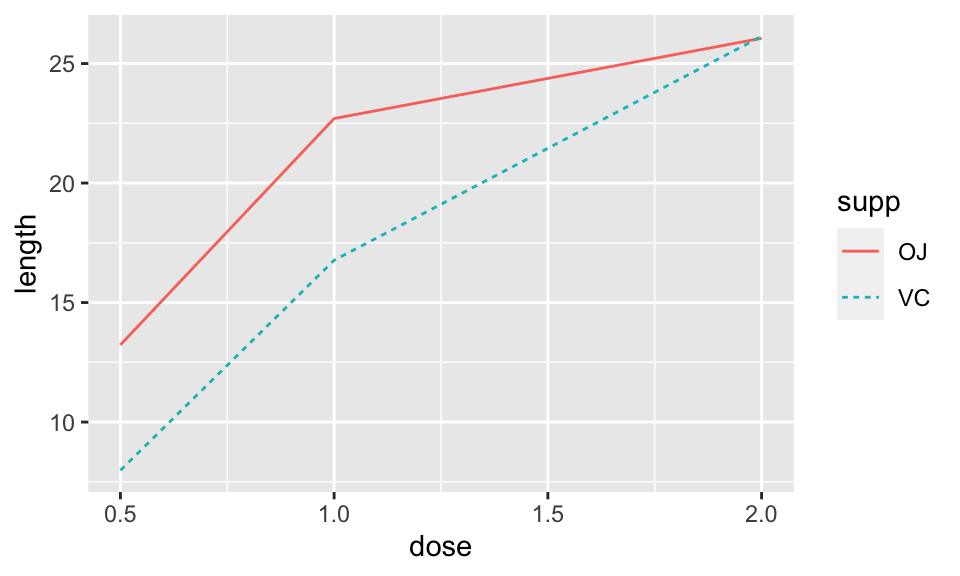

```r
# map supp to linetype
ggplot(tg, aes(x = dose, y = length, color = supp, linetype = supp)) + geom_line()
```

- `ddpply(ToothGrowth, c(‘supp’, ‘dose’), summarise, length = mean(len))` : 변수 supp, dose 의 조합에 대하여 변수 len의 값들의 평균을 계산하여 length라는 이름의 변수에 저장하여 data frame으로 출력.
- `color = supp` , `linetype = supp` 은 그림에 나타나게 될 선의 색상, 선의 모양을 supp 변수의 값에 따라 다르게 나타나도록 설정.

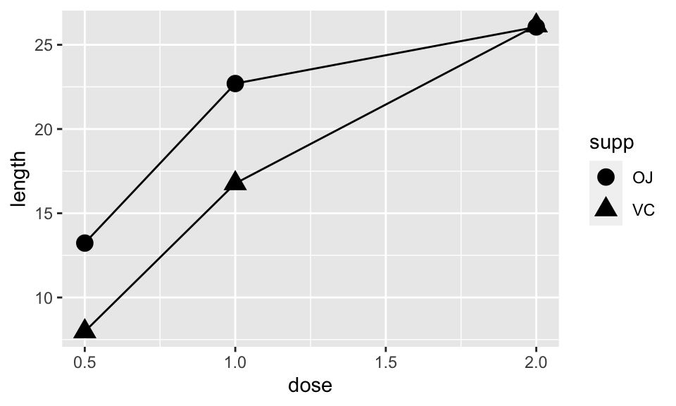

```r
ggplot(tg, aes(x = dose, y = length, shape = supp)) + geom_line() +
  geom_point(size = 4)
```

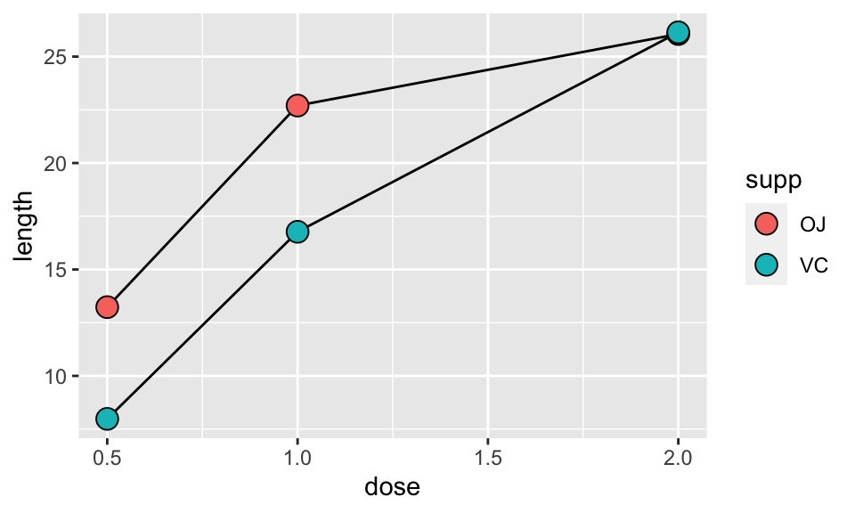

```r
ggplot(tg, aes(x = dose, y = length, fill = supp)) + geom_line() +
  geom_point(size = 4, shape = 21)
```

- `ggplot(..., shape = supp)` : 그림에 나타날 점의 모양을 변수 supp 값에 따라 다르게 표시.
- `geom_point(size = 4, shape = 21)` : 점의 크기를 4로 하고, 모양을 21로 함. 21에 해당하는 점의 모양은 안이 빈 원(circle) 임.
- `ggplot(..., aes(..., fill = supp))` 이므로 원의 빈 영역에 채울 색상을 변수 supp 값에 따라 다르게 출력함.

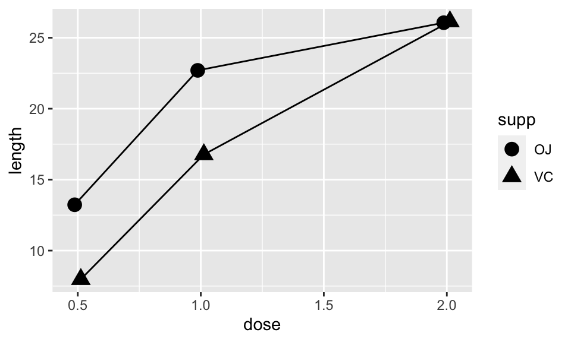

```r
ggplot(tg, aes(x = dose, y = length, shape = supp)) +
  geom_line(position = position_dodge(0.05)) +
  geom_point(position = position_dodge(0.05), size = 4)
```

- `position = position_dodge()` : 그려질 점, 선을 그룹별로 side-by-side로 놓여지도록 수평방향으로 옮김. 점들이 겹치는 현상을 피하는데 이용.
- `geom_line()` 및 `geom_point()`에 동일한 dodge level을 갖도록 함에 유의.

## Changing the Appearance of Lines and Points

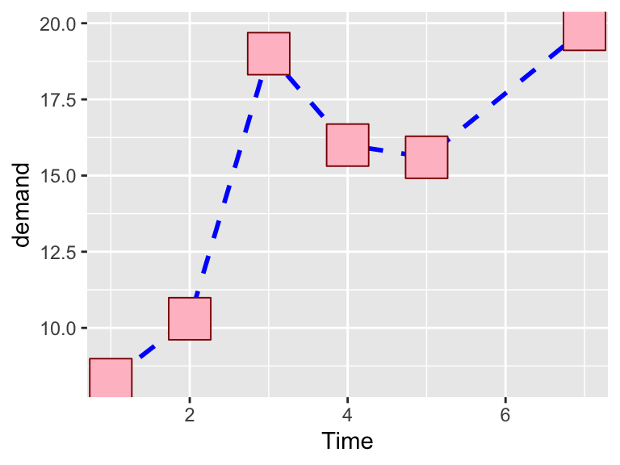

```r
ggplot(BOD, aes(x = Time, y = demand)) +
  geom_line(linetype = 'dashed', size = 1, color = 'blue') +
  geom_point(size = 10, shape = 22, color = 'darkred', fill = 'pink')
```

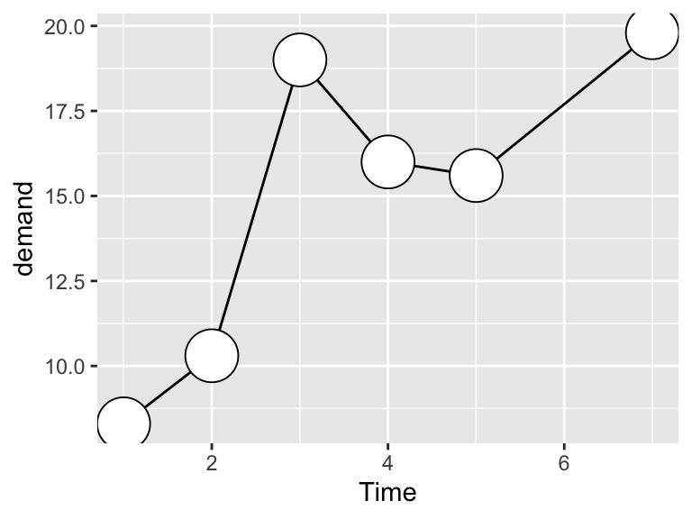

```r
ggplot(BOD, aes(x = Time, y = demand)) + geom_line() +
  geom_point(size = 10, shape = 21, fill = 'white')
```

- shape = 21, 22에 대응하는 점의 모양은 안이 빈 형태로 fill을 이용하여 색상을 지정할 수 있음. 이러한 경우 점의 테두리는 color를 통해, 점의 내부는 fill을 통해 색상을 지정함.

## Making a Graph with a Shaded Area

```r
str(sunspot.year)
```

```
##  Time-Series [1:289] from 1700 to 1988: 5 11 16 23 36 58 29 20 10 8 ...
```

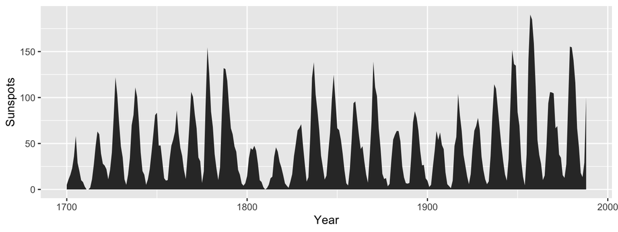

```r
sunspotyear <- data.frame(
  Year = as.numeric(time(sunspot.year)),
  Sunspots = as.numeric(sunspot.year)
)
ggplot(sunspotyear, aes(x = Year, y = Sunspots)) + geom_area()
```

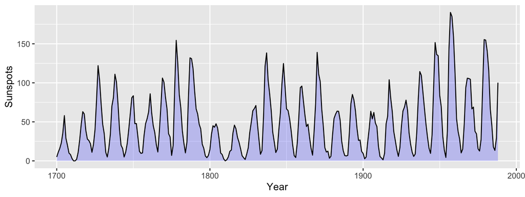

```r
ggplot(sunspotyear, aes(x = Year, y = Sunspots)) +
  geom_area(fill = 'blue', alpha = 0.2) + geom_line()
```

- 데이터 sunspotyear는 data frame으로 변수는 Year (numeric), Sunspots (numeric) 임.
- `time(sunspot.year)`는 ts 객체인 sunspot.year의 시간정보를 추출함.
- `as.numeric(sunspot.year)`는 ts 객체인 sunspot.year를 numeric 객체로 타입을 변환함. 따라서 ts객체의 성질이 사라짐.
- `geom_area()`는 line의 아래부분에 음영을 주어 영역표시를 함.
- `alpha = 0.2`는 영역색의 투명도를 조절함. (0-투명, 1-불투명)

## Making a Stacked Area Graph

```r
str(uspopage)
```

```
## 'data.frame':    824 obs. of  3 variables:
##  $ Year     : int  1900 1900 1900 1900 1900 1900 1900 1900 1901 1901 ...
##  $ AgeGroup : Factor w/ 8 levels "<5","5-14","15-24",..: 1 2 3 4 5 6 7 8 1 2 ...
##  $ Thousands: int  9181 16966 14951 12161 9273 6437 4026 3099 9336 17158 ...
```

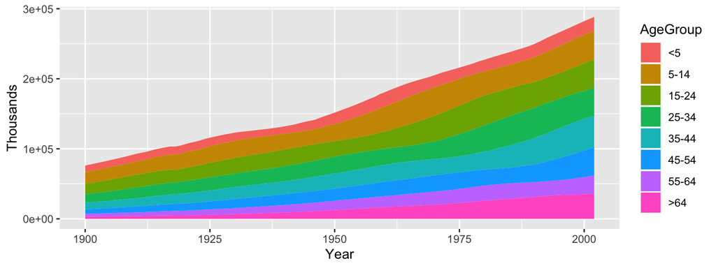

```r
ggplot(uspopage, aes(x = Year, y = Thousands, fill = AgeGroup)) + geom_area()
```

- `geom_area()`와 더불어 aes() 함수에 `fill = AgeGroup`을 추가함으로써 area를 변수 AgeGroup의 레벨별로 다른 색상을 부여함으로 stacked area graph를 얻음.

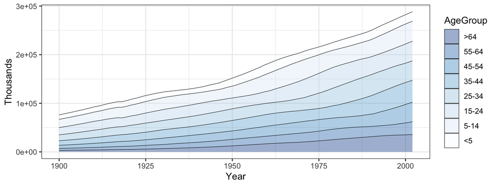

```r
p <- ggplot(uspopage, aes(x = Year, y = Thousands, fill = AgeGroup))

p +  geom_area(color = 'black', size = 0.2, alpha = 0.4) +
  scale_fill_brewer(palette = 'Blues', breaks = rev(levels(uspopage$AgeGroup))) +
  theme_bw()
```

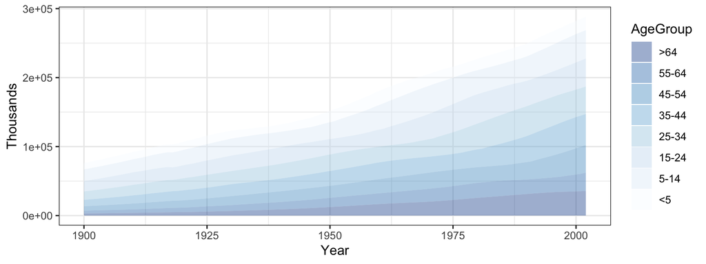

```r
p <- ggplot(uspopage, aes(x = Year, y = Thousands, fill = AgeGroup))
p +  geom_area(color = NA, size = 0.2, alpha = 0.4) +
  scale_fill_brewer(palette = 'Blues', breaks = rev(levels(uspopage$AgeGroup))) +
  theme_bw()
```

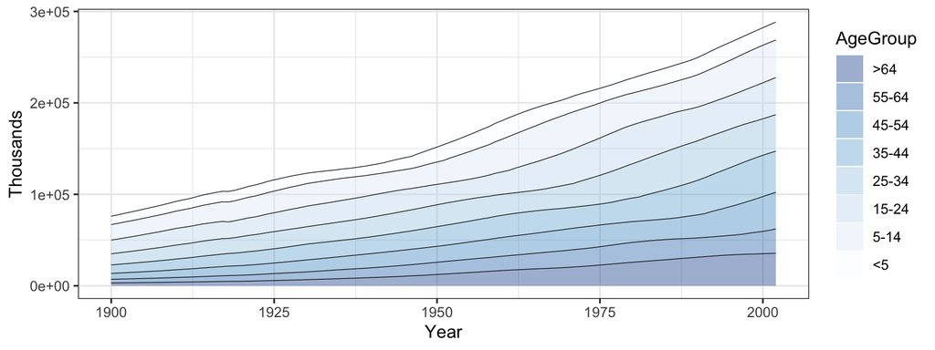

```r
# removing the border only for legend
p +  geom_area(color = NA, size = 0.2, alpha = 0.4) +
  scale_fill_brewer(palette = 'Blues', breaks = rev(levels(uspopage$AgeGroup))) +
  geom_line(position = 'stack', size = 0.2) +
  theme_bw()
```

- `color = NA` : area 간의 구분선을 없앰.
- 두번째 그림에서 `geom_line(position = ‘stack’)`을 추가함으로써 범례상의 구분선은 없애고 그래프 상의 구분선은 추가함.

## Adding a Confidence Region

```r
str(climate)
```

```
## 'data.frame':    499 obs. of  6 variables:
##  $ Source    : chr  "Berkeley" "Berkeley" "Berkeley" "Berkeley" ...
##  $ Year      : num  1800 1801 1802 1803 1804 ...
##  $ Anomaly1y : num  NA NA NA NA NA NA NA NA NA NA ...
##  $ Anomaly5y : num  NA NA NA NA NA NA NA NA NA NA ...
##  $ Anomaly10y: num  -0.435 -0.453 -0.46 -0.493 -0.536 -0.541 -0.59 -0.695 -0.763 -0.818 ...
##  $ Unc10y    : num  0.505 0.493 0.486 0.489 0.483 0.475 0.468 0.461 0.453 0.451 ...
```

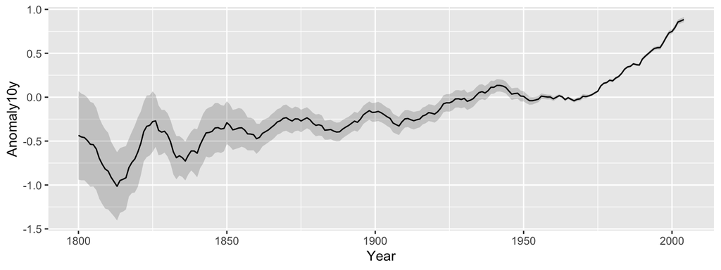

```r
clim <- subset(climate, Source == 'Berkeley',
               select = c('Year', 'Anomaly10y', 'Unc10y'))
p <- ggplot(clim, aes(x = Year, y = Anomaly10y))
# shaded region
p + geom_ribbon(aes(ymin = Anomaly10y - Unc10y, ymax = Anomaly10y + Unc10y), alpha = 0.2) +
  geom_line()
```

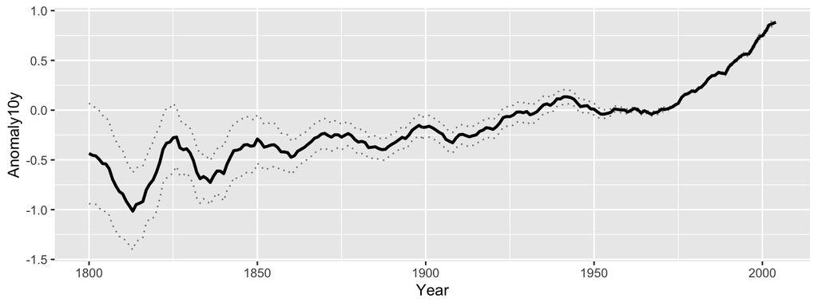

```r
# dotted lines
p + geom_line(aes(y = Anomaly10y - Unc10y), color = 'grey50', linetype = 'dotted') +
  geom_line(aes(y = Anomaly10y + Unc10y), color = 'grey50', linetype = 'dotted') +
  geom_line(lwd = 1)
```

- `geom_ribbon(aes(ymin = , ymax = ))` : confidence band를 출력.
- `geom_line()`을 통해 confidence band 표시 가능.